[figure not shown]

# Jesse Wriedt Answers for GEICO `Position` in data science

# Q#1 Answer: Work Authoriziation

## Yes, I can work up to 40 hrs/ week.

# Q#2 Answer: Work sponsorship

## Yes, I will need that after 4 yrs.

# Q#3 Answer: Base Salary

## I am expect to get something between $ (55K to 60K) annualy.

# Q#4 Answer: I am ok with DC area

# Q#5 Answer: Transcript now in the application

# Skills `Rating`

- ## Building predictive models

  > 8 out of 10, 6-7 yrs.  
  > Last month in my PhD proposal and my first published paper at INFORMS for “optimal offline experimentation for games” we build a design of experiment model to check the adequacy of significant factors selection. Then, we used regression model to estimate the main and two-way interaction effects for the defender-attacker variables in linear and non-linear models.
- ## Python programming

> 8 out of 10, 5-6 yrs.

> In the entire my M.S. and Ph.D. studies I almost Python every week. The last use was on the project for on-going research to find what so-called equilibriums in cybersecurity games, using capture-the-flag (CTF) framework in cooperation with university of Cincinnati. Most librires used are: numpy, sklearn, seaborn, beautifulsoup, pandas, sciPy and matplotlib.

```python
## Need to include the data to work

from numpy import genfromtxt
import nashpy as nash
import numpy as np
import re
import time
start = time. time()
f = open("add.txt", "w")  # create add file in write mode


NashC= [0.0, 0.0, 1.0, 0.0, 0.0, 0.0, 0.0, 0.0, 0.0, 0.0, 1.0, 0.0, 0.0, 0.0]
A = genfromtxt('A.csv', delimiter=',')
B = genfromtxt('B.csv', delimiter=',')
num_of_runs = 10
STD_A = 2.74
STD_B = 3.65
SOl = []
for i in range(num_of_runs):
    AA = A
    BB = B
    Noise_A = np.random.randn(6, 8) * STD_A
    Noise_B = np.random.randn(6, 8) * STD_B
    A = A + Noise_A
    B = B + Noise_B
    game = nash.Game(A, B)

    for eq in game.support_enumeration():
        print(i)
        print(eq)
        SOl.append(eq)
print("Now the summary")
count = 0
for t in range(len(SOl)):
    y=str(SOl[t])
    dd = [float(s) for s in re.findall(r'-?\d+\.?\d*', y)]
    if dd == NashC:
        count = count +1
    print(dd)
print(t)
print("number of matched is ", count)
print("the fraction of the candidate Nash equilibria is ", count / num_of_runs)
end = time. time()
print("The Total Time is ", end - start)
```

[output not shown]

- ## R programming

  > 8/10, 4 yrs  
  > Freelancer projects from khamsat.com platform. I used to find the basic statistics for a client building a logistic regression model with data visualization dashboard.
- ## Other languages (Java, C++, etc.) or statistical software (SAS, SPSS, MatLab, etc.)

> 6.5/10, 6 yrs

> Honestly, I heavily use C, SAS, and Matlab but not Java/spss. Also use them for my on-going research almost similar for the python usage. SAS project was 6 month ago for a client in the medical application using PROC mixed for postmenstrual age for infants from 28 to 34 weeks.

## Here is a sample of SAS code

```python
## libname library 'H:\My Documents\UF CON\PhD Program\Dissertations\****\2019\Data-Based\20190910';

''' Code will not run since it is A SAS code ....


* subject	Session	Group	Gender	power	condition	logpower;


proc mixed data=library.mtw_khlood ic covtest plots=all;
class subject session group gender condition;
ID subject;
model logpower = group gender session condition

/*
I started with all these 2-way interactions in the model.
I removed non-significant ones in the order below, and checked for improved BIC.
This is the final, best-fitting model.
Note that an ARMA(1,1) type covariance structure fit best.
Use of a random intercept reduced model fit (BIC was increased).
*/

/*
condition*group
condition*gender
session*group
session*condition
gender*group
session*gender
*/

/ htype=3 ;
* random intercept / subject=subject type=vc;
* random intercept effect worse BIC - do not include;

* arh1: 1635;
* arma(1,1): 1578;

repeated  session*condition / subject=subject type=arma(1,1);

lsmeans group gender session condition / cl diff ;

run; quit;
##
```

- ## SQL in relational databases

  > 6/10, 4 yrs  
  > The last use was with my IBM data science certificate last week.
- ## Working in a Unix/Linux environment

  > 7 out of 10, 5yrs I use Linux and Kali linux for the cybersecurity experimentation and utilize the penetration tools in Metasploit, nmap, Aircrack-ng and wireshark for the data collection data phase for the NSF research.
- ## Hadoop data manipulation and use of Spark

> 5.5-6/10, 3 yrs.

> The last use was with my IBM data science certificate last week.
- ## Other big data or distributed computing experience

> 5.5/10, 3 yrs .

> Online courses exercises nothing related to my research or clients’ project.
- ## Data visualization

> 8 / 10, 6 yrs.

> Last use was representing the class grades [Enginnering Project Management at Ohio State](https://ise.osu.edu/courses/engineering-project-management-3800-0), and edited version of Corona virus spread in the US credited to powerbi.microsoft.com. [Edited from PowerBI.microsoft.com](https://powerbi.microsoft.com) © Microsoft

## This project was part of IBM data science certificate

> Data visualization course [Course is Here](https://www.coursera.org/learn/python-for-data-visualization)

> Crime Map in San Francisco

```python
import numpy as np  # useful for many scientific computing in Python
import pandas as pd # primary data structure library

!conda install -c conda-forge folium=0.5.0 --yes
import folium

print('Folium installed and imported!')

df_incidents = pd.read_csv('https://cocl.us/sanfran_crime_dataset', index_col=0,)
df_incidents.rename(columns={'PdDistrict':'Neighborhood'}, inplace=True)
df_incidents_1 = df_incidents.groupby(['Neighborhood']).size().reset_index(name='Count')
df_incidents_1


# download countries geojson file
!wget --quiet https://cocl.us/sanfran_geojson -O world_countries.json

sanfran_geo = r'world_countries.json' # geojson file

# create a plain world map
sanfran_map = folium.Map(location=[37.77,-122.42], zoom_start=12)

# generate choropleth map
sanfran_map.choropleth(
    geo_data=sanfran_geo,
    data=df_incidents_1,
    columns=['Neighborhood', 'Count'],
    key_on='feature.properties.DISTRICT',
    fill_color='YlOrRd',
    fill_opacity=0.7,
    line_opacity=0.2,
    legend_name='Crime Rate in San Francisco'
)

# display map
sanfran_map
```

```
Solving environment: done

# All requested packages already installed.

Folium installed and imported!
```

[interactive chart not shown]

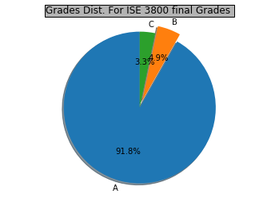

```python
import matplotlib.pyplot as plt

# Pie chart, where the slices will be ordered and plotted counter-clockwise:
labels = 'A', 'B', 'C'
sizes = [56, 3, 2]
explode = (0, 0.1, 0)  # only "explode" the 2nd slice (i.e. 'Hogs')

fig1, ax1 = plt.subplots()
ax1.pie(sizes, explode=explode, labels=labels, autopct='%0.1f%%',
        shadow=True, startangle=90)
ax1.axis('equal')  # Equal aspect ratio ensures that pie is drawn as a circle.
plt.title("Grades Dist. For ISE 3800 final Grades ", bbox={'facecolor':'0.7', 'pad':1})

plt.show()
```

[interactive chart not shown]